# Analysis

EGillette

2025-02-26

https://github.com/EmiliagG/Rentrez

## DNA Sequence Analysis - Part One

```r
Sequences_data<-read.table("https://raw.githubusercontent.com/EmiliagG/Rentrez/main/Sequences.csv", header=T, sep="," )
library(dplyr)

#print each sequence
print(c("Sequence 1: HQ433692.1, B.burgdorferi",Sequences_data$Sequence[1], "Sequence 2: HQ433694.1, B.burgdorferi",Sequences_data$Sequence[2],"Sequence 3: HQ433691.1, B.burgdorferi", Sequences_data$Sequence[3]))
```

```
## [1] "Sequence 1: HQ433692.1, B.burgdorferi"
## [2] "AGCATGCAAGTCAAACGAGATGTAGCAATACATCTAGTGGCGAACGGGTGAGTAACGCGT…"
## [3] "Sequence 2: HQ433694.1, B.burgdorferi"
## [4] "AGCATGCAAGTCAAACGGGATGTAGCAATACATTCAGTGGCGAACGGGTGAGTAACGCGT…"
## [5] "Sequence 3: HQ433691.1, B.burgdorferi"
## [6] "AGCATGCAAGTCAAACGAGATGTAGTAATACATCTAGTGGCGAACGGGTGAGTAACGCGT…"
```

```r
#counting the number of base pairs in each sequence
A_bp<-c()
T_bp<-c()
G_bp<-c()
C_bp <-c()

for(item in Sequences_data$Sequence){
    A_bp<-c(A_bp, nchar(gsub("[^A]","",item)))
    T_bp<-c(T_bp, nchar(gsub("[^T]", "", item)))
    G_bp<-c(G_bp, nchar(gsub("[^G]", "", item)))
    C_bp<-c(C_bp, nchar(gsub("[^C]", "", item)))
}

SequenceID=c("HQ433692.1","HQ433694.1","HQ433691.1")

no_bp<-data.frame(SequenceID=SequenceID,
                  A=A_bp,T=T_bp,G=G_bp,C=C_bp)

as.table(as.matrix(no_bp))
```

```
##   SequenceID A   T   G   C
## A HQ433692.1 154 114 131 82
## B HQ433694.1 155 114 131 81
## C HQ433691.1 154 115 131 81
```

**Table 1.** The number of nucleotide base pairs (A, T, G, or C) present in the three different *B.burgdorferi* sequences.

```r
#calculate the total number of bp in each sequence
total_bp<-c()
for (item in Sequences_data$Sequence) {
  total_bp<-c(total_bp, nchar(item))
}

#calculate GC_Content
GC<-no_bp %>%
  group_by(SequenceID) %>%
  summarize(GC_Content=(round(((sum(G,C)/481)*100),digits=2)))
colnames(GC)[2]<-"GC Content (%)"

as.table(as.matrix(GC))
```

```
##   SequenceID GC Content (%)
## A HQ433691.1 44.07
## B HQ433692.1 44.28
## C HQ433694.1 44.07
```

**Table 2.** Content (%) of G and C nucleotides present in three *B. burgdorferi* sequences.

Link to Wikipedia with more information about *Borrelia burgdorferi*: https://en.wikipedia.org/wiki/Borrelia_burgdorferi

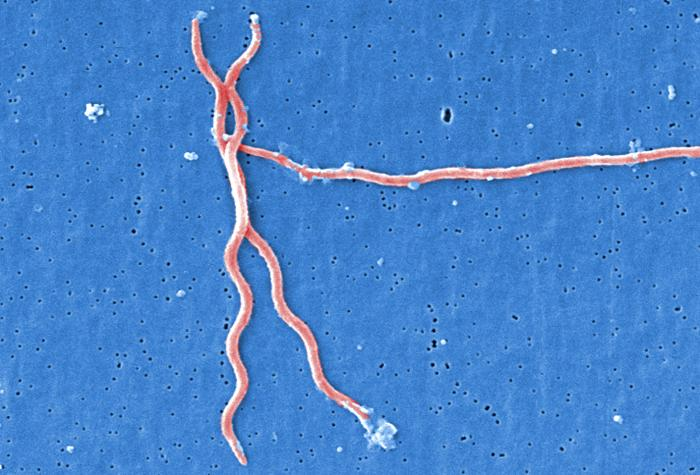

**Figure 1.** Scanning electron microsope image of the bacteria *Borrelia burgdorferi*, from the Center for Disease Control’s Public Image Library, 2011, https://phil.cdc.gov/Details.aspx?pid=13177

## Part Two

```r
library(BiocManager)
library(annotate)
library(dplyr)

unknownSeq<-read.delim("https://raw.githubusercontent.com/EmiliagG/Rentrez/main/UknownSeq.fa.txt")
#str(unknownSeq)
#head(unknownSeq$X..Human.isolate..unknown.sequence)

unknownSeq2<-paste(unknownSeq$X..Human.isolate..unknown.sequence[1],
                   unknownSeq$X..Human.isolate..unknown.sequence[2],
                   unknownSeq$X..Human.isolate..unknown.sequence[3],
                   unknownSeq$X..Human.isolate..unknown.sequence[4],
                   unknownSeq$X..Human.isolate..unknown.sequence[5])
#unknownSeq2
unknownSeq2<-gsub(" ", "", unknownSeq2)
#unknownSeq2

unknownBlastDF<-blastSequences(unknownSeq2,hitListSize=50,
                               as='data.frame',timeout=5000)
#nrow(unknownBlastDF)
#str(unknownBlastDF)
hits1<-unknownBlastDF %>%
  group_by(Hit_def) %>%
  summarize(Hsp_evalue)
#hits1

hits2<-unknownBlastDF %>%
  group_by(Hit_def) %>%
  summarize(Hsp_score)
#hits2

tb<-unknownBlastDF %>%
  group_by(Hit_accession) %>%
  summarize(Hit_def,Hsp_score, Hsp_evalue, Hsp_gaps)
tb
```

```
## # A tibble: 326 × 5
## # Groups:   Hit_accession [50]
##    Hit_accession Hit_def                           Hsp_score Hsp_evalue Hsp_gaps
##    <chr>         <chr>                             <chr>     <chr>      <chr>
##  1 CP177372      Yersinia pestis strain 90044 chr… 500       1.35431e-… 0
##  2 CP177372      Yersinia pestis strain 90044 chr… 500       1.35431e-… 0
##  3 CP177372      Yersinia pestis strain 90044 chr… 500       1.35431e-… 0
##  4 CP177372      Yersinia pestis strain 90044 chr… 500       1.35431e-… 0
##  5 CP177372      Yersinia pestis strain 90044 chr… 500       1.35431e-… 0
##  6 CP177372      Yersinia pestis strain 90044 chr… 500       1.35431e-… 0
##  7 CP177372      Yersinia pestis strain 90044 chr… 500       1.35431e-… 0
##  8 CP177412      Yersinia pestis strain 38004 chr… 500       1.35431e-… 0
##  9 CP177412      Yersinia pestis strain 38004 chr… 500       1.35431e-… 0
## 10 CP177412      Yersinia pestis strain 38004 chr… 500       1.35431e-… 0
## # ℹ 316 more rows
```

**Table 3**. Output of the blastSequences (blastn) search of GenBank to identify a match for the unknown DNA strand (nrow=326).

Using Basic Local Alignment Search Tool (BLAST) there is evidence the unknown DNA sequence provided to the Canadian Public Health Agency is a strain of *Yersinia pestis*. *Y.pestis* is the bacteria responsible for Plague, known in European history as the “Black Death,” making this an infection of high concern (Harvard Health Publishing, 2024).Comparing the unknown DNA sequence to sequeces in NCBI’s GenBank revealed over 300 matches with zero gaps between the query sequence and the GenBank matches, and high-scoring segment pair values of 500 (Table 3).

Reference Harvard Health Publishing.(2024, May 21). *Plague (Yersinia Pestis)*. Accessed at: https://www.health.harvard.edu/a_to_z/plague-yersinia-pestis-a-to-z